# Scoring bulk gene expression samples with PhenoMapR

Brooks Benard

2026-03-09

## Overview

This vignette is an **example of using PhenoMapR to score bulk RNA-seq samples** and to **show that the resulting score stratifies outcome**. PhenoMapR has built-in pan-cancer outcomes meta-z score signatures from [PRECOG](https://precog.stanford.edu/). To demonstrate that PhenoMapR can assign prognostic risk to patient samples profiled by bulk RNAseq, we use the GSE205154 dataset: **289 primary and metastatic pancreatic ductal adenocarcinoma (PDAC)** samples with gene expression and overall survival (Sears et al.). Pre-processed gene expression and cleaned clinical annotations were obtained from [PRECOG](https://precog.stanford.edu/). After scoring samples with PhenoMapR’s built-in PRECOG references, we stratify by score (high vs low) and demonstrate that the PhenoMapR score separates survival in both primary and metastatic groups.

**Data files** (downloadable from [PRECOG](https://precog.stanford.edu/)):

- `GSE205154.GPL20301.matrix.txt` — normalized expression (genes × samples)
- `GSE205154.info.txt` — sample annotations (Tumor_Type: Primary / Met, OS_Time, OS_Status, Specimen_Site when available)

## 1. Load bulk expression and clinical annotations for GSE205154

Load the expression matrix and clinical info so we can score samples with PhenoMapR and link scores to outcome.

```r
knitr::opts_chunk$set(fig.width = 6, fig.height = 6, fig.align = "center")
suppressPackageStartupMessages(library(PhenoMapR))

# Files in the same directory as this vignette
vignette_dir <- if (dir.exists("Vignettes")) "Vignettes" else "."
info_path <- file.path(vignette_dir, "GSE205154.info.txt")
matrix_path <- file.path(vignette_dir, "GSE205154.GPL20301.matrix.txt")
if (!file.exists(info_path)) {
  info_path <- "GSE205154.info.txt"
  matrix_path <- "GSE205154.GPL20301.matrix.txt"
}
has_data <- file.exists(info_path) && file.exists(matrix_path)
knitr::opts_chunk$set(eval = has_data)
if (!has_data) {
  message("GSE205154 data files not found. See Vignettes/README.md for download instructions.")
} else {
  # Clinical annotations: Array = sample ID, Tumor_Type = Primary/Met, OS_Time, OS_Status, Specimen_Site (when available)
  info <- read.delim(info_path, stringsAsFactors = FALSE, check.names = FALSE)
  colnames(info)[colnames(info) == "Array"] <- "sample_id"
  info$tumor_type <- info$Tumor_Type
  site_col <- intersect(c("Specimen_Site", "Specimen.Site"), colnames(info))[1]
  if (!is.na(site_col)) info$specimen_site <- info[[site_col]]
  info$survival_time <- as.numeric(info$OS_Time) / 365.25  # convert to years
  info$survival_event <- as.integer(info$OS_Status)
  info <- info[!is.na(info$survival_time) & !is.na(info$survival_event), ]

  # Expression matrix: Gene (ENSG), Name (symbol), then GSM columns
  mat <- read.delim(matrix_path, stringsAsFactors = FALSE, check.names = FALSE)
  # Use gene symbol (Name); keep first of duplicates, drop empty/NA
  mat$Name[mat$Name == "" | is.na(mat$Name)] <- NA
  mat <- mat[!is.na(mat$Name), ]
  mat <- mat[!duplicated(mat$Name), ]
  rownames(mat) <- mat$Name
  sample_cols <- grep("^GSM", colnames(mat), value = TRUE)
  bulk_mat <- as.matrix(mat[, sample_cols])
  mode(bulk_mat) <- "numeric"

  # Align to samples in clinical info
  keep <- intersect(colnames(bulk_mat), info$sample_id)
  bulk_mat <- bulk_mat[, keep, drop = FALSE]
  pheno <- info[info$sample_id %in% keep, ]
  pheno <- pheno[match(keep, pheno$sample_id), ]
  rownames(pheno) <- pheno$sample_id

  message("Expression: ", nrow(bulk_mat), " genes × ", ncol(bulk_mat), " samples")
  message("Phenotype: ", nrow(pheno), " samples (Primary: ", sum(pheno$tumor_type == "Primary"), ", Met: ", sum(pheno$tumor_type == "Met"), ")")
}
```

```
## Expression: 38562 genes × 289 samples
```

```
## Phenotype: 289 samples (Primary: 218, Met: 71)
```

## 2. Score bulk samples with PhenoMapR

Score all samples with PhenoMapR using the built-in meta-z score signatures for Adult PRECOG **Pancreatic** (primary) and **Pancreatic_Metastasis**. By assigning a prognostic risk score to the samples, we should be able to identify patients expressing more adversely prognostic signatures as well as more favorably prognostic signatures and this should stratify outcomes.

```r
# To assign a PhenoMap score to each sample, pass the bulk gene expression matrix
# to the expression argument, select the reference database to score against (can
# be one of: precog, tcga, pediatric_precog, or ici_precog, and specify the cancer
# type to score against (use list_cancer_types(reference = "precog") to see available
# cancer types)

# Score all samples using the Primary PAAD signature
scores_primary <- PhenoMap(
  expression = bulk_mat,
  reference = "precog",
  cancer_type = "Pancreatic",
  verbose = TRUE
)
```

```
## Detected input type: matrix
```

```
## 7376 genes used for scoring against PancreaticCalculating scores...
## Completed scoring for Pancreatic
```

```r
# Score all samples using the Metastatic PAAD signature
scores_met <- PhenoMap(
  expression = bulk_mat,
  reference = "precog",
  cancer_type = "Pancreatic_Metastasis",
  verbose = TRUE
)
```

```
## Detected input type: matrix
```

```
## 2997 genes used for scoring against Pancreatic_MetastasisCalculating scores...
## Completed scoring for Pancreatic_Metastasis
```

```r
# make a combined dataframe of sample clinical annotations and PhenoMap scores
col_pan <- grep("Pancreatic$", colnames(scores_primary), value = TRUE)[1]
col_met <- grep("Pancreatic_Metastasis", colnames(scores_met), value = TRUE)[1]
scores_df <- data.frame(
  sample_id = rownames(scores_primary),
  score_Pancreatic = if (!is.na(col_pan)) scores_primary[[col_pan]] else NA_real_,
  score_Pancreatic_Metastasis = if (!is.na(col_met)) scores_met[[col_met]] else NA_real_,
  stringsAsFactors = FALSE
)
dat <- merge(pheno, scores_df, by = "sample_id")
```

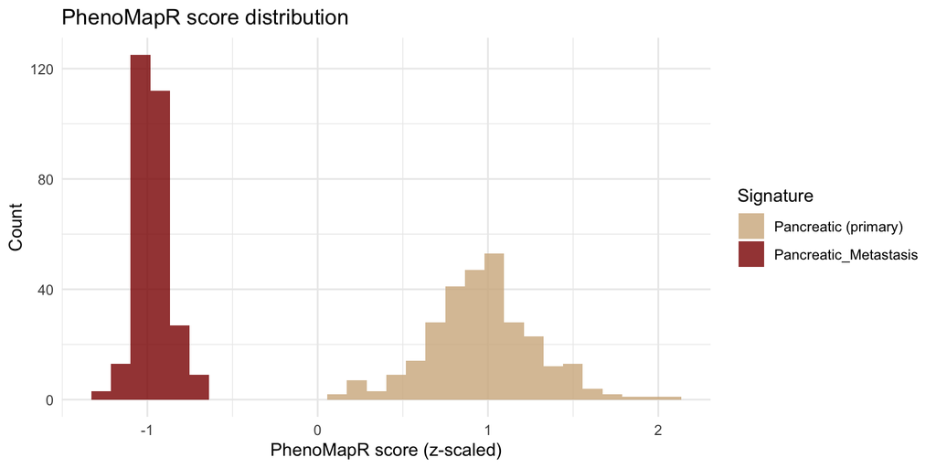

```r
# Summary histogram: Primary and Metastatic PhenoMapR scores (z-scaled)
suppressPackageStartupMessages(library(ggplot2))
score_long <- data.frame(
  score = c(dat$score_Pancreatic, dat$score_Pancreatic_Metastasis),
  type = rep(c("Pancreatic (primary)", "Pancreatic_Metastasis"), each = nrow(dat))
)
score_long$score_z <- as.numeric(scale(score_long$score))
ggplot(score_long, aes(x = score_z, fill = type)) +
  geom_histogram(alpha = 0.8, position = "identity", bins = 30) +
  scale_fill_manual(values = c("Pancreatic (primary)" = "tan", "Pancreatic_Metastasis" = "darkred")) +
  labs(x = "PhenoMapR score (z-scaled)", y = "Count", fill = "Signature", title = "PhenoMapR score distribution") +
  theme_minimal()
```

## 3. Primary vs Metastatic outcomes

Before seeing if PhenoMapR scores stratify outcomes, let’s see if the primary and metastatic patients in the study show differences in outcomes.

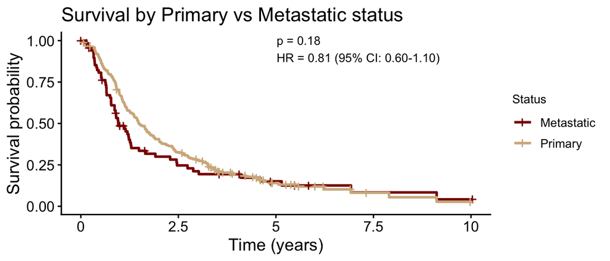

```r
suppressPackageStartupMessages(library(survival))
suppressPackageStartupMessages(library(survminer))
# Unnamed vector: order matches strata (Met first, then Primary). Named palettes trigger scale warnings.
pal_tumor <- c("darkred", "tan")  # Metastatic, Primary

fit_primary <- survfit(Surv(survival_time, survival_event) ~ tumor_type, data = dat)
lr_primary <- survdiff(Surv(survival_time, survival_event) ~ tumor_type, data = dat)
pval_primary <- 1 - pchisq(lr_primary$chisq, 1)
cox_primary <- coxph(Surv(survival_time, survival_event) ~ tumor_type, data = dat)
hr_primary <- exp(coef(cox_primary))[1]
ci_primary <- as.vector(exp(confint(cox_primary)))
label_primary <- sprintf("p = %s\nHR = %.2f (95%% CI: %.2f-%.2f)",
  format.pval(pval_primary, digits = 2, eps = 0.001), hr_primary, ci_primary[1], ci_primary[2])
max_time_primary <- max(dat$survival_time, na.rm = TRUE)
ggsurvplot(fit_primary, data = dat, palette = pal_tumor, risk.table = FALSE,
           title = "Survival by Primary vs Metastatic status",
           xlab = "Time (years)", ylab = "Survival probability", legend.title = "Status",
           legend.labs = c("Metastatic", "Primary"), legend = "right",
           pval = label_primary, pval.coord = c(max_time_primary * 0.5, 0.95), pval.size = 3.5)
```

It seems like patients with metastatic disease trend towards worse outcomes but it’s not statistically significant.

## 4. Primary tumors: PhenoMapR stratifies outcome

Stratify primary samples by PhenoMapR score (high vs low median split) and show that the **Pancreatic** score stratifies survival.

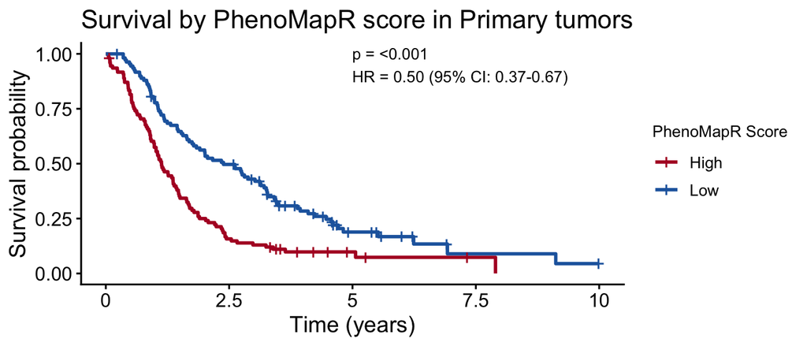

```r
# Unnamed vector: order matches strata (High first, then Low). Named palettes can trigger scale warnings.
pal_km <- c("#B2182B", "#2166AC")  # High (adverse), Low (favorable)
dat_primary <- dat[dat$tumor_type == "Primary", ]
dat_primary$score_grp <- ifelse(
  dat_primary$score_Pancreatic >= median(dat_primary$score_Pancreatic, na.rm = TRUE),
  "High", "Low"
)
fit_primary <- survfit(Surv(survival_time, survival_event) ~ score_grp, data = dat_primary)
lr_primary <- survdiff(Surv(survival_time, survival_event) ~ score_grp, data = dat_primary)
pval_primary <- 1 - pchisq(lr_primary$chisq, 1)
cox_primary <- coxph(Surv(survival_time, survival_event) ~ score_grp, data = dat_primary)
hr_primary <- exp(coef(cox_primary))[1]
ci_primary <- as.vector(exp(confint(cox_primary)))
label_primary <- sprintf("p = %s\nHR = %.2f (95%% CI: %.2f-%.2f)",
  format.pval(pval_primary, digits = 2, eps = 0.001), hr_primary, ci_primary[1], ci_primary[2])
max_time_primary <- max(dat_primary$survival_time, na.rm = TRUE)
ggsurvplot(fit_primary, data = dat_primary, palette = pal_km, risk.table = FALSE,
           title = "Survival by PhenoMapR score in Primary tumors",
           xlab = "Time (years)", ylab = "Survival probability", legend.title = "PhenoMapR Score",
           legend.labs = c("High", "Low"), legend = "right",
           pval = label_primary, pval.coord = c(max_time_primary * 0.5, 0.95), pval.size = 3.5)
```

## 5. Metastatic samples: PhenoMapR stratifies outcome

Stratify metastatic samples by PhenoMapR score (high vs low median split) and show that the **Pancreatic_Metastasis** score stratifies survival in this subset.

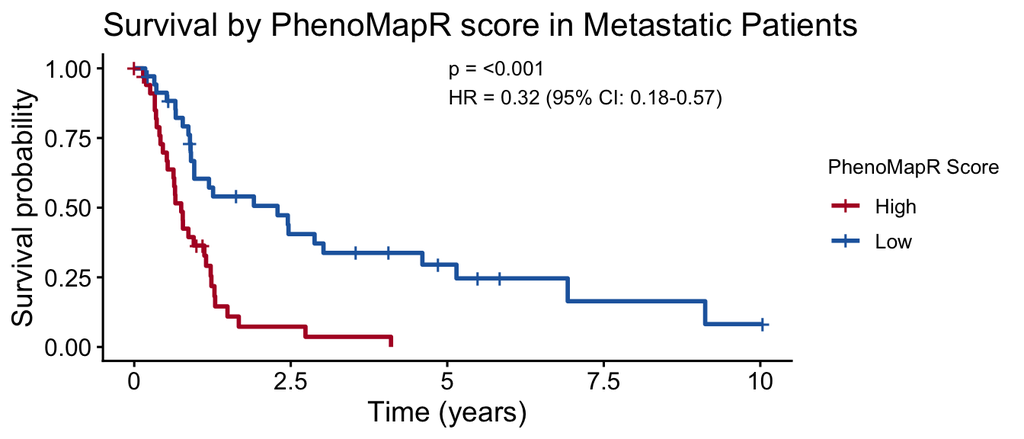

```r
dat_met <- dat[dat$tumor_type == "Met", ]
dat_met$score_grp <- ifelse(
  dat_met$score_Pancreatic_Metastasis >= median(dat_met$score_Pancreatic_Metastasis, na.rm = TRUE),
  "High", "Low"
)
fit_met <- survfit(Surv(survival_time, survival_event) ~ score_grp, data = dat_met)
lr_met <- survdiff(Surv(survival_time, survival_event) ~ score_grp, data = dat_met)
pval_met <- 1 - pchisq(lr_met$chisq, 1)
cox_met <- coxph(Surv(survival_time, survival_event) ~ score_grp, data = dat_met)
hr_met <- exp(coef(cox_met))[1]
ci_met <- as.vector(exp(confint(cox_met)))
label_met <- sprintf("p = %s\nHR = %.2f (95%% CI: %.2f-%.2f)",
  format.pval(pval_met, digits = 2, eps = 0.001), hr_met, ci_met[1], ci_met[2])
max_time_met <- max(dat_met$survival_time, na.rm = TRUE)
ggsurvplot(fit_met, data = dat_met, palette = pal_km, risk.table = FALSE,
           title = "Survival by PhenoMapR score in Metastatic Patients",
           xlab = "Time (years)", ylab = "Survival probability", legend.title = "PhenoMapR Score",
           legend.labs = c("High", "Low"), legend = "right",
           pval = label_met, pval.coord = c(max_time_met * 0.5, 0.95), pval.size = 3.5)
```

## 6. Summary

PhenoMapR can take a bulk expression dataset and assign prognostic risk scores and significantly stratify outcomes in both primary and metastatic disease in PAAD. In this case, we had access to outcomes annotations for the cohort but it is reasonable to assume many datasets profiled with bulk gene expression do not have outcomes data available or reported. In these cases, PhenoMapR can nominate samples that are on the extremes of the phenotype space (e.g. survival) and help define sample groupings.

## 7. References

- **GSE205154**: Sears et al. Bulk RNA-Seq gene expression for 289 primary and metastatic PDAC samples. *Nature Cancer* (2025). [GEO: GSE205154](https://www.ncbi.nlm.nih.gov/geo/query/acc.cgi?acc=GSE205154).
- **PRECOG**: Benard B et al. PRECOG update: an augmented resource of clinical outcome associations with gene expression for adult, pediatric, and immunotherapy cohorts. *Nucleic Acids Research* (2025). [precog.stanford.edu](https://precog.stanford.edu/); [PubMed: 40909678](https://pubmed.ncbi.nlm.nih.gov/40909678/).